# Lookup Database Creation for ConversationAlign

Jamie Reilly, Ginny Ulichney, Ben Sacks

July 21, 2024

# Prep lookup_db

https://stats.stackexchange.com/questions/281162/scale-a-number-between-a-range

For details on where each of the variables below was drawn from, visit:

https://reilly-lab.github.io/ConversationAlign_LookupDatabaseCreation.html

# Load pre-built lookup_db

```r
load(here("original_dbases", "lookup_db.rda"))
str(lookup_db)
```

```
## 'data.frame':    102682 obs. of  31 variables:
##  $ word                 : chr  "a" "aa" "aaa" "aaaa" ...
##  $ aff_anger            : num  2.87 2.54 2.07 1.94 2.55 ...
##  $ aff_anxiety          : num  2.27 1.69 2.27 1.8 2.29 ...
##  $ aff_boredom          : num  3 2.08 2.82 2.37 2.46 ...
##  $ aff_closeness        : num  2.77 1.95 1.29 1.62 1.76 ...
##  $ aff_confusion        : num  1.448 0.744 1.287 1.505 2.144 ...
##  $ aff_dominance        : num  NA NA NA NA NA ...
##  $ aff_doubt            : num  2.59 1.05 1.34 1.49 1.49 ...
##  $ aff_empathy          : num  2.43 2.22 1.48 1.84 1.83 ...
##  $ aff_encouragement    : num  2.67 2.28 2.3 2.54 2.39 ...
##  $ aff_excitement       : num  2.83 3.19 2.63 3.1 2.78 ...
##  $ aff_guilt            : num  3.06 2.79 2.65 2.47 2.47 ...
##  $ aff_happiness        : num  3.21 3.62 2.99 3.22 3.39 ...
##  $ aff_hope             : num  3.3 3.31 2.96 3.36 2.64 ...
```

[output cut: 17 more lines]

```r
colnames(lookup_db)
```

```
##  [1] "word"                  "aff_anger"             "aff_anxiety"
##  [4] "aff_boredom"           "aff_closeness"         "aff_confusion"
##  [7] "aff_dominance"         "aff_doubt"             "aff_empathy"
## [10] "aff_encouragement"     "aff_excitement"        "aff_guilt"
## [13] "aff_happiness"         "aff_hope"              "aff_hostility"
## [16] "aff_politeness"        "aff_sadness"           "aff_stress"
## [19] "aff_surprise"          "aff_trust"             "aff_valence"
## [22] "lex_age_acquisition"   "lex_letter_count_raw"  "lex_morphemecount_raw"
## [25] "lex_prevalence"        "lex_senses_polysemy"   "lex_wordfreqlg10_raw"
## [28] "sem_arousal"           "sem_concreteness"      "sem_diversity"
## [31] "sem_neighbors"
```

```r
# write.csv(lookup_db, 'lookup_db.csv')
```

# Count and summary

by variable for appendix/table.

```r
howmany <- function(x) {
    sum(!is.na(x))
}
# CountCompCases(lookup_db)
longlook <- lookup_db %>%
    pivot_longer(2:31, names_to = "dimension", values_to = "salience")
tapply(longlook$salience, longlook$dimension, howmany)
```

```
##             aff_anger           aff_anxiety           aff_boredom
##                 76427                 76427                 76427
##         aff_closeness         aff_confusion         aff_dominance
##                 76427                 76427                 19971
##             aff_doubt           aff_empathy     aff_encouragement
##                 76427                 76427                 76427
##        aff_excitement             aff_guilt         aff_happiness
##                 76427                 76427                 76427
##              aff_hope         aff_hostility        aff_politeness
##                 76427                 76427                 76427
##           aff_sadness            aff_stress          aff_surprise
##                 76427                 76427                 76427
##             aff_trust           aff_valence   lex_age_acquisition
##                 76427                 19971                 31104
##  lex_letter_count_raw lex_morphemecount_raw        lex_prevalence
##                 95462                 51531                 46237
##   lex_senses_polysemy  lex_wordfreqlg10_raw           sem_arousal
##                 36408                 60384                 19971
##      sem_concreteness         sem_diversity         sem_neighbors
##                 39576                 29613                 45871
```

```r
tapply(longlook$salience, longlook$dimension, summary)
```

```
## $aff_anger
##    Min. 1st Qu.  Median    Mean 3rd Qu.    Max.    NA's
##   0.000   2.409   2.729   2.754   3.062  10.000   26255
##
## $aff_anxiety
##    Min. 1st Qu.  Median    Mean 3rd Qu.    Max.    NA's
##   0.000   2.328   2.649   2.683   2.993  10.000   26255
##
## $aff_boredom
##    Min. 1st Qu.  Median    Mean 3rd Qu.    Max.    NA's
##   0.000   2.226   2.595   2.654   3.012  10.000   26255
##
## $aff_closeness
##    Min. 1st Qu.  Median    Mean 3rd Qu.    Max.    NA's
##   0.000   1.767   2.113   2.150   2.490  10.000   26255
##
## $aff_confusion
##    Min. 1st Qu.  Median    Mean 3rd Qu.    Max.    NA's
##   0.000   1.733   2.086   2.139   2.480  10.000   26255
##
## $aff_dominance
##    Min. 1st Qu.  Median    Mean 3rd Qu.    Max.    NA's
##    0.00    3.49    4.62    4.81    6.08   10.00   82711
##
## $aff_doubt
##    Min. 1st Qu.  Median    Mean 3rd Qu.    Max.    NA's
##   0.000   1.623   1.951   1.977   2.298  10.000   26255
##
## $aff_empathy
##    Min. 1st Qu.  Median    Mean 3rd Qu.    Max.    NA's
##   0.000   1.865   2.203   2.261   2.587  10.000   26255
##
## $aff_encouragement
##    Min. 1st Qu.  Median    Mean 3rd Qu.    Max.    NA's
##   0.000   1.953   2.314   2.344   2.684  10.000   26255
##
## $aff_excitement
##    Min. 1st Qu.  Median    Mean 3rd Qu.    Max.    NA's
##   0.000   2.738   3.069   3.071   3.401  10.000   26255
##
```

[output cut: 64 more lines]

```
## $sem_arousal
##    Min. 1st Qu.  Median    Mean 3rd Qu.    Max.    NA's
##    0.00    3.49    4.60    4.81    6.00   10.00   82711
##
## $sem_concreteness
##    Min. 1st Qu.  Median    Mean 3rd Qu.    Max.    NA's
##    0.00    2.73    4.60    5.02    7.17   10.00   63106
##
## $sem_diversity
##    Min. 1st Qu.  Median    Mean 3rd Qu.    Max.    NA's
##    0.00    5.14    6.24    6.10    7.22   10.00   73069
##
## $sem_neighbors
##    Min. 1st Qu.  Median    Mean 3rd Qu.    Max.    NA's
##    0.00    0.00    0.00    0.81    0.00   10.00   56811
```

# Distributions

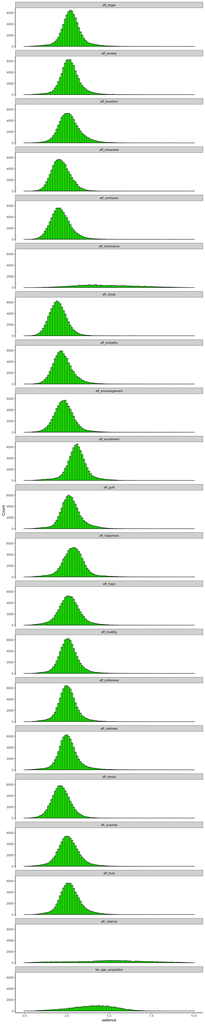

```r
# isolate all vars on a 0:10 scale first
justto10 <- lookup_db %>%
    select(1:22)
long10 <- justto10 %>%
    pivot_longer(2:22, names_to = "dimension", values_to = "salience")
ggplot(long10, aes(x = salience), fill = dimension) + geom_histogram(binwidth = 0.1,
    fill = "green", color = "black") + ylab("Count") + jamie.theme + facet_wrap(~dimension,
    ncol = 1)
```

```r
print(longlook)
```

```
## # A tibble: 3,080,460 × 3
##    word  dimension         salience
##    <chr> <chr>                <dbl>
##  1 a     aff_anger             2.87
##  2 a     aff_anxiety           2.27
##  3 a     aff_boredom           3.00
##  4 a     aff_closeness         2.77
##  5 a     aff_confusion         1.45
##  6 a     aff_dominance        NA
##  7 a     aff_doubt             2.59
##  8 a     aff_empathy           2.43
##  9 a     aff_encouragement     2.67
## 10 a     aff_excitement        2.83
## # ℹ 3,080,450 more rows
```

# Build lookup_db from scratch

## Affectvec

```r
base <- read.csv(here("original_dbases", "db_affectvec.csv"))
affectsmall <- base %>%
    select(word, surprise, trust, anger, sadness, anxiety, boredom, confusion, excitement,
        encouragement, stress, empathy, hostility, closeness, doubt, happiness, guilt,
        hope, politeness)
word <- tolower(affectsmall$word)
affectsmall <- affectsmall %>%
    select(!word)
# append aff- suffix to all variables
affectsmall <- affectsmall %>%
    rename_with(.fn = function(.x) {
        paste0("aff_", .x)
    })
# append aff- to each variable str(affectsmall)
affectsmall[1:ncol(affectsmall)] <- lapply(affectsmall[1:ncol(affectsmall)], function(x) rescale(x,
    to = c(0, 10)))
lookup_db <- cbind(word, affectsmall)
str(lookup_db)
```

## Age of acquisition

Add the Kuperman norms to the lookup database, Yoke and rescale to 0 to 10

```r
kup <- read.csv(here("original_dbases", "db_kuperman_aoa.csv"))
kup_aoa <- kup %>%
    select(word, kup_aoa) %>%
    na.omit  #retain complete cases
word <- kup_aoa$word
kup_aoa <- kup_aoa %>%
    select(!word)
dat <- kup_aoa %>%
    mutate(lex_age_acquisition = rescale(kup_aoa, to = c(0, 10))) %>%
    select(!kup_aoa)
dat <- cbind(word, dat)
lookup_db <- lookup_db %>%
    full_join(dat, by = "word")
lookup_db <- lookup_db %>%
    distinct(word, .keep_all = TRUE)
str(lookup_db)
```

## Arousal, valence, dominance

NRC VAD Lexicon. Add valence, arousal, dominance ratings and reescale to 0 to 10  
https://saifmohammad.com/WebPages/nrc-vad.html

```r
nrc <- read.csv(here("original_dbases", "db_nrc_vad.csv"))
nrc[2:ncol(nrc)] <- lapply(nrc[2:ncol(nrc)], function(x) rescale(x, to = c(0, 10)))
word <- tolower(nrc$word)  #make sure all entries lowercase
nrc <- nrc %>%
    rename(aff_valence = "valence")
nrc <- nrc %>%
    rename(aff_dominance = "dominance")
nrc <- nrc %>%
    rename(sem_arousal = "arousal")
nrc <- nrc %>%
    select(!word)
nrc <- cbind(word, nrc)
# no need to select specific columns or omit NAs in this one
lookup_db <- lookup_db %>%
    full_join(nrc, by = "word")
lookup_db <- lookup_db %>%
    distinct(word, .keep_all = TRUE)  #keeps first entry
```

## Concreteness

Rescale from the Brysbaert norms

```r
cnc_raw <- read.csv(here("original_dbases", "db_brysbaert_cnc.csv"))  #read in raw data
cnc_small <- cnc_raw %>%
    select(word, brys_concreteness)  # select word and concreteness rating
cnc_rescale <- cnc_small %>%
    mutate(sem_concreteness = rescale(brys_concreteness, to = c(0, 10))) %>%
    select(!brys_concreteness)
cnc_rescale <- cnc_rescale %>%
    distinct(word, .keep_all = TRUE)  #retain only first entry
word <- tolower(cnc_rescale$word)  #make sure all entries lowercase in separate vector
cnc_rescale <- cnc_rescale %>%
    select(!word)  #kill word column
dat2 <- cbind(word, cnc_rescale)  #bind word column back in
str(dat2)
lookup_db <- lookup_db %>%
    full_join(dat2, by = "word")
```

## Word length

nletter count raw — UNSCALED

```r
# use str_length to generate letter count per word as new var called n_letters
lookup_db <- lookup_db %>%
    mutate(lex_letter_count_raw = stringr::str_length(word))
```

## Word frequency

US Subtlex — UNSCALED Lg frequency

```r
subtlex <- read.csv(here("original_dbases", "db_subtlex_clean.csv"))
dat <- subtlex %>%
    select(word, lg10wf)
dat <- dat %>%
    distinct(word, .keep_all = TRUE)  #retain only first entry
word <- tolower(dat$word)  #make sure all entries lowercase in separate vector
dat <- dat %>%
    rename(lex_wordfreqlg10_raw = "lg10wf")
dat <- dat %>%
    select(!word)
dat <- cbind(word, dat)  #bind word column back in
lookup_db <- lookup_db %>%
    full_join(dat, by = "word")
lookup_db <- lookup_db %>%
    select(order(colnames(lookup_db)))
lookup_db <- lookup_db %>%
    distinct(word, .keep_all = TRUE)
```

## Morphemes per word

Merge the following values from the South Carolina (SCOPE) metabasefrom morpholex database into SCOPE

```r
# database is already converted to lowercase all
scope <- read.csv(here("original_dbases", "db_scope_aug23rev.csv"))
dat <- scope %>%
    rename(lex_morphemecount_raw = "morpheme_count")
dat <- dat %>%
    distinct(word, .keep_all = TRUE)
```

## Semantic neighborhoods

from Shaoul and Westbury https://www.psych.ualberta.ca/~westburylab/downloads/westburylab.arcs.ncounts.html Number of semantic neighbors based on distance in co-occurence space

```r
dat <- dat %>%
    mutate(sem_neighbors = rescale(semantic_neighbors, to = c(0, 10))) %>%
    select(!semantic_neighbors)
```

## Polysemy (word senses from WordNet)

https://wordnet.princeton.edu/ number of senses from Wordnet database

```r
dat <- dat %>%
    mutate(lex_senses_polysemy = rescale(nsenses, to = c(0, 10))) %>%
    select(!nsenses)
```

## Semantic diversity

Rescaled semantic diversity from Hoffman et al.  
https://link.springer.com/article/10.3758/s13428-012-0278-x#SecESM1 The degree to which different contexts associated with a word vary in their meaning

```r
dat <- dat %>%
    mutate(sem_diversity = rescale(semantic_diversity, to = c(0, 10))) %>%
    select(!semantic_diversity)
```

## Prevalence

From brysbaert et al (how many people know a word)

```r
dat <- dat %>%
    mutate(lex_prevalence = rescale(prevalence, to = c(0, 10))) %>%
    select(!prevalence)
```

## Export

Sort columns alphabetically, save as rda and export with system date appended to filname.

```r
# check for duplicates Reorder so word is first
lookup_db <- lookup_db %>%
    full_join(dat, by = "word")
lookup_db <- lookup_db %>%
    select(order(colnames(lookup_db)))
lookup_db <- lookup_db %>%
    distinct(word, .keep_all = TRUE)
colnames(lookup_db)
lookup_db <- lookup_db[, c(31, 1:30)]  #reorder so word is first
currentDate <- Sys.Date()
save(lookup_db, file = paste("lookup_db", currentDate, ".rda", sep = "-"))
```